# Mini_Project_ML1_Task2_3_60009210068

# Observations:

1.There are outliers in smoker and charges.

**But we are not going to drop outliers as there is corelation between these features and target.**

# Scaling:

```python
#Standard Scaling
from sklearn.preprocessing import StandardScaler
scaler=StandardScaler()
df_scaled=df.drop(["insuranceclaim"],axis=1)
df_scaled
df_scaled_1=scaler.fit_transform(df_scaled)
```

```python
#Converting it into dataframe:
df_scaled=pd.DataFrame(df_scaled_1,columns=df_scaled.columns)
df_scaled.head()
```

|  | age | sex | bmi | steps | children | smoker | region | charges |
| --- | --- | --- | --- | --- | --- | --- | --- | --- |
| 0 | -1.44 | -1.01 | -0.45 | -0.95 | -0.91 | 1.97 | 1.34 | 0.30 |
| 1 | -1.51 | 0.99 | 0.51 | -0.95 | -0.08 | -0.51 | 0.44 | -0.95 |
| 2 | -0.80 | 0.99 | 0.38 | -0.95 | 1.58 | -0.51 | 0.44 | -0.73 |
| 3 | -0.44 | 0.99 | -1.31 | 1.91 | -0.91 | -0.51 | -0.47 | 0.72 |
| 4 | -0.51 | 0.99 | -0.29 | 1.09 | -0.91 | -0.51 | -0.47 | -0.78 |

# Next, we will select the best model for our problem by evaluating various models on the dataset and selecting the one with the highest performance.

```python
#Dividing Data into Training and Testing Set
X=df_scaled
y=df["insuranceclaim"]
print("X Shape: ",X.shape)
print("y Shape: ", y.shape)
```

```
X Shape:  (1338, 8)
y Shape:  (1338,)
```

```python
from sklearn.model_selection import train_test_split
X_train,X_test,y_train,y_test=train_test_split(X,y,test_size=0.2,random_state=42)
print("X_train: ",X_train.shape)
print("X_test: ",X_test.shape)
print("y_train: ",y_train.shape)
print("y_test: ",y_test.shape)
```

```
X_train:  (1070, 8)
X_test:  (268, 8)
y_train:  (1070,)
y_test:  (268,)
```

# 1.Logistic Regression

```python
from sklearn.linear_model import LogisticRegression
lr=LogisticRegression()
lr.fit(X_train,y_train)
#Accuracy On training set
print("Accuracy on training : ",lr.score(X_train,y_train))
#Accuracy On testing set
print("Accuracy on testing : ",lr.score(X_test,y_test))
```

```
Accuracy on training :  0.8897196261682243
Accuracy on testing :  0.8619402985074627
```

```python
from sklearn.metrics import confusion_matrix,accuracy_score,recall_score,precision_score,f1_score,roc_auc_score,roc_curve
y_pred=lr.predict(X_test)
print("confusion matrix:\n",
      confusion_matrix(y_test,y_pred))
print("\n")
print("Accuracy score:" ,accuracy_score(y_test,y_pred))
print("recall: ",recall_score(y_test,y_pred))
print("Precison: ",precision_score(y_test,y_pred))
print("F1-score: ", f1_score(y_test,y_pred))
print("Specifity: ",confusion_matrix(y_test, y_pred)[0,0] / (confusion_matrix(y_test, y_pred)[0,0] + confusion_matrix(y_test, y_pred)[0,1]))
```

```
confusion matrix:
 [[ 92  15]
 [ 22 139]]


Accuracy score: 0.8619402985074627
recall:  0.8633540372670807
Precison:  0.9025974025974026
F1-score:  0.8825396825396825
Specifity:  0.8598130841121495
```

```python
auc=roc_auc_score(y_test,y_pred)
print("auc : ",auc)
```

```
auc :  0.8615835606896151
```

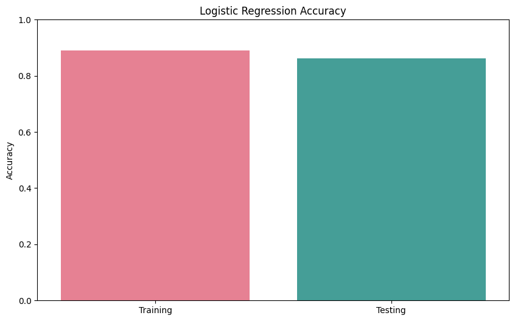

```python
train_acc = lr.score(X_train, y_train)
test_acc = lr.score(X_test, y_test)

# plot the results
plt.figure(figsize=(10,6))
sns.barplot(x=['Training', 'Testing'], y=[train_acc, test_acc],palette="husl",)
plt.ylim([0, 1])
plt.ylabel('Accuracy')
plt.title('Logistic Regression Accuracy')
plt.show()
```

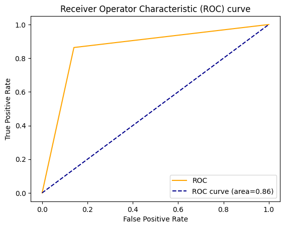

```python
auc=roc_auc_score(y_test,y_pred)
fpr, tpr, thresholds = roc_curve(y_test, y_pred)
plt.plot(fpr, tpr, color="orange", label="ROC")
plt.plot([0,1], [0,1], color="darkblue", linestyle="--", label="ROC curve (area=%0.2f)" % auc)
plt.xlabel("False Positive Rate")
plt.ylabel("True Positive Rate")
plt.title("Receiver Operator Characteristic (ROC) curve")
plt.legend()
plt.show()
```

# 2.Naive Bayes

```python
from sklearn.naive_bayes import GaussianNB
nb=GaussianNB()
nb.fit(X_train,y_train)
#Accuracy On training set
print("Accuracy on training : ",nb.score(X_train,y_train))
#Accuracy On testing set
print("Accuracy on testing : ",nb.score(X_test,y_test))
```

```
Accuracy on training :  0.811214953271028
Accuracy on testing :  0.7947761194029851
```

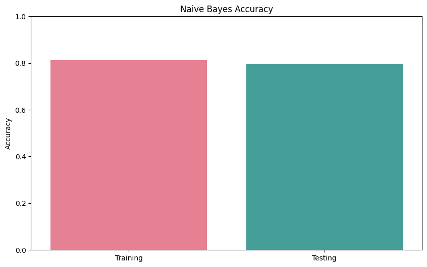

```python
train_acc = nb.score(X_train, y_train)
test_acc = nb.score(X_test, y_test)

# plot the results
plt.figure(figsize=(10,6))
sns.barplot(x=['Training', 'Testing'], y=[train_acc, test_acc],palette="husl",)
plt.ylim([0, 1])
plt.ylabel('Accuracy')
plt.title('Naive Bayes Accuracy')
plt.show()
```

# 3.Decision Tree

```python
from sklearn.tree import DecisionTreeClassifier
dt=DecisionTreeClassifier()
dt.fit(X_train,y_train)
```

```
DecisionTreeClassifier()
```

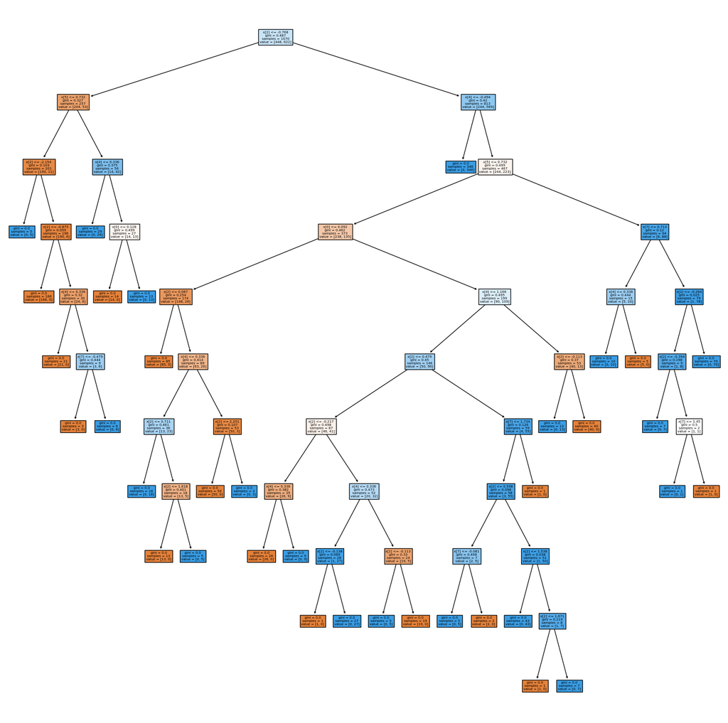

```python
#Visualizing Tree
from sklearn import tree
plt.figure(figsize=(20,20))
tree.plot_tree(dt.fit(X_train,y_train),filled=True)
plt.show()
```

```python
#Accuracy On training set
print("Accuracy on training : ",dt.score(X_train,y_train))
#Accuracy On testing set
print("Accuracy on testing : ",dt.score(X_test,y_test))
```

```
Accuracy on training :  1.0
Accuracy on testing :  0.9738805970149254
```

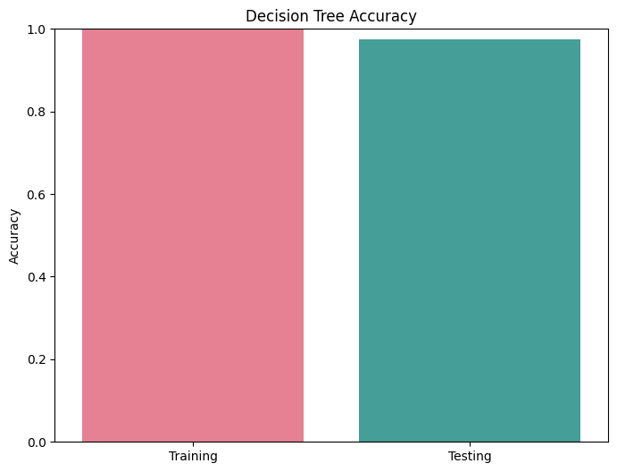

```python
train_acc = dt.score(X_train, y_train)
test_acc = dt.score(X_test, y_test)

# plot the results
plt.figure(figsize=(8,6))
sns.barplot(x=['Training', 'Testing'], y=[train_acc, test_acc],palette="husl",)
plt.ylim([0, 1])
plt.ylabel('Accuracy')
plt.title('Decision Tree Accuracy')
plt.show()
```

```
confusion matrix:
 [[102   5]
 [  2 159]]
Accuracy score: 0.9738805970149254
recall:  0.9875776397515528
Precison:  0.9695121951219512
F1-score:  0.9784615384615385
Specifity:  0.9532710280373832
```

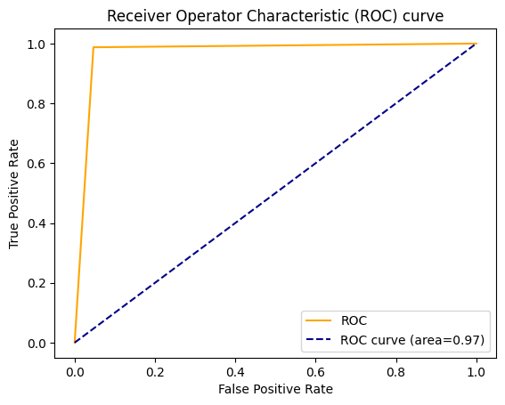

```python
y_pred=dt.predict(X_test)
print("confusion matrix:\n",
      confusion_matrix(y_test,y_pred))

print("Accuracy score:" ,accuracy_score(y_test,y_pred))
print("recall: ",recall_score(y_test,y_pred))
print("Precison: ",precision_score(y_test,y_pred))
print("F1-score: ", f1_score(y_test,y_pred))
print("Specifity: ",confusion_matrix(y_test, y_pred)[0,0] / (confusion_matrix(y_test, y_pred)[0,0] + confusion_matrix(y_test, y_pred)[0,1]))
auc=roc_auc_score(y_test,y_pred)
fpr, tpr, thresholds = roc_curve(y_test, y_pred)
plt.plot(fpr, tpr, color="orange", label="ROC")
plt.plot([0,1], [0,1], color="darkblue", linestyle="--", label="ROC curve (area=%0.2f)" % auc)
plt.xlabel("False Positive Rate")
plt.ylabel("True Positive Rate")
plt.title("Receiver Operator Characteristic (ROC) curve")
plt.legend()
plt.show()
```

# **In decison tree there is no need of scaling lets see if there is any change on accuracy with non-scaled data**

```python
#Dividing Data into Training and Testing Set
X_dt=df.drop(["insuranceclaim"],axis=1)
y_dt=df["insuranceclaim"]
print("X Shape without scaled: ",X_dt.shape)
print("y Shape without scaled: ", y_dt.shape)
from sklearn.model_selection import train_test_split
X_train_dt,X_test_dt,y_train_dt,y_test_dt=train_test_split(X,y,test_size=0.2,random_state=42)
print("X_train without scaled: ",X_train_dt.shape)
print("X_test without scaled: ",X_test_dt.shape)
print("y_train without scaled: ",y_train_dt.shape)
print("y_test without scaled: ",y_test_dt.shape)
from sklearn.tree import DecisionTreeClassifier
dt=DecisionTreeClassifier()
dt.fit(X_train_dt,y_train_dt)
#Accuracy On training set
print("Accuracy on training without scaled: ",dt.score(X_train_dt,y_train_dt))
#Accuracy On testing set
print("Accuracy on testing without scaled : ",dt.score(X_test_dt,y_test_dt))
```

```
X Shape without scaled:  (1338, 8)
y Shape without scaled:  (1338,)
X_train without scaled:  (1070, 8)
X_test without scaled:  (268, 8)
y_train without scaled:  (1070,)
y_test without scaled:  (268,)
Accuracy on training without scaled:  1.0
Accuracy on testing without scaled :  0.9850746268656716
```

# RESULTS:

We'll follow our approach with going with scaled data.

# 4.Random Forest

```python
from sklearn.ensemble import RandomForestClassifier
rf=RandomForestClassifier()
rf.fit(X_train,y_train)
```

```
RandomForestClassifier()
```

```python
#Accuracy On training set
print("Accuracy on training : ",rf.score(X_train,y_train))
#Accuracy On testing set
print("Accuracy on testing : ",rf.score(X_test,y_test))
```

```
Accuracy on training :  1.0
Accuracy on testing :  0.9477611940298507
```

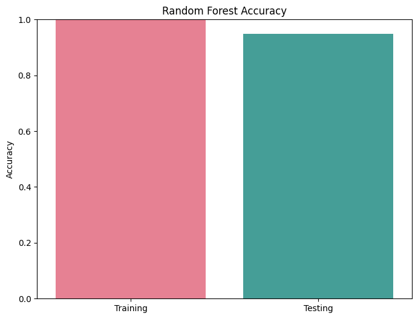

```python
train_acc = rf.score(X_train, y_train)
test_acc = rf.score(X_test, y_test)

# plot the results
plt.figure(figsize=(8,6))
sns.barplot(x=['Training', 'Testing'], y=[train_acc, test_acc],palette="husl",)
plt.ylim([0, 1])
plt.ylabel('Accuracy')
plt.title('Random Forest Accuracy')
plt.show()
```

```
confusion matrix:
 [[103   4]
 [ 10 151]]
Accuracy score: 0.9477611940298507
recall:  0.937888198757764
Precison:  0.9741935483870968
F1-score:  0.9556962025316457
Specifity:  0.9626168224299065
```

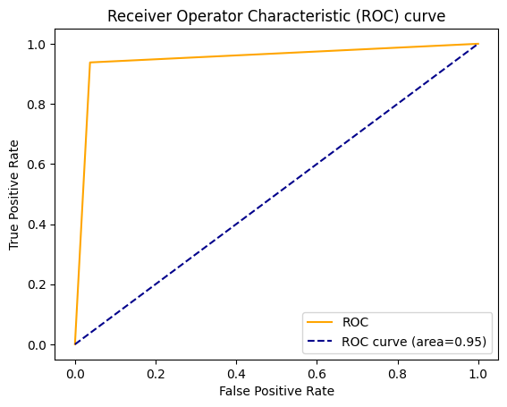

```python
y_pred=rf.predict(X_test)
print("confusion matrix:\n",
      confusion_matrix(y_test,y_pred))

print("Accuracy score:" ,accuracy_score(y_test,y_pred))
print("recall: ",recall_score(y_test,y_pred))
print("Precison: ",precision_score(y_test,y_pred))
print("F1-score: ", f1_score(y_test,y_pred))
print("Specifity: ",confusion_matrix(y_test, y_pred)[0,0] / (confusion_matrix(y_test, y_pred)[0,0] + confusion_matrix(y_test, y_pred)[0,1]))
auc=roc_auc_score(y_test,y_pred)
fpr, tpr, thresholds = roc_curve(y_test, y_pred)
plt.plot(fpr, tpr, color="orange", label="ROC")
plt.plot([0,1], [0,1], color="darkblue", linestyle="--", label="ROC curve (area=%0.2f)" % auc)
plt.xlabel("False Positive Rate")
plt.ylabel("True Positive Rate")
plt.title("Receiver Operator Characteristic (ROC) curve")
plt.legend()
plt.show()
```

**RESULTS:**

1.Accuracy is not good than Decison Tree infact it has degraded.

# 5.XG Boost

```python
import xgboost
from xgboost import XGBClassifier
xg=XGBClassifier()
xg.fit(X_train,y_train)
```

```
XGBClassifier(base_score=None, booster=None, callbacks=None,
              colsample_bylevel=None, colsample_bynode=None,
              colsample_bytree=None, early_stopping_rounds=None,
              enable_categorical=False, eval_metric=None, feature_types=None,
              gamma=None, gpu_id=None, grow_policy=None, importance_type=None,
              interaction_constraints=None, learning_rate=None, max_bin=None,
              max_cat_threshold=None, max_cat_to_onehot=None,
              max_delta_step=None, max_depth=None, max_leaves=None,
              min_child_weight=None, missing=nan, monotone_constraints=None,
              n_estimators=100, n_jobs=None, num_parallel_tree=None,
              predictor=None, random_state=None, ...)
```

```python
#Accuracy On training set
print("Accuracy on training : ",xg.score(X_train,y_train))
#Accuracy On testing set
print("Accuracy on testing : ",xg.score(X_test,y_test))
```

```
Accuracy on training :  1.0
Accuracy on testing :  0.9626865671641791
```

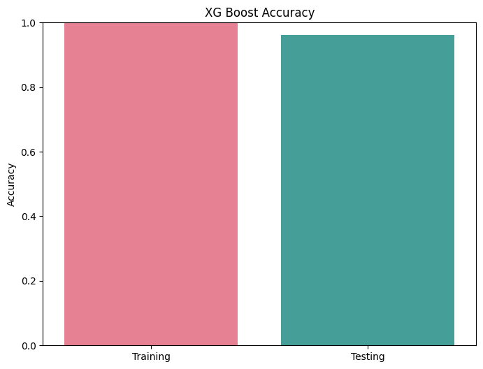

```python
train_acc = xg.score(X_train, y_train)
test_acc = xg.score(X_test, y_test)

# plot the results
plt.figure(figsize=(8,6))
sns.barplot(x=['Training', 'Testing'], y=[train_acc, test_acc],palette="husl",)
plt.ylim([0, 1])
plt.ylabel('Accuracy')
plt.title('XG Boost Accuracy')
plt.show()
```

```
confusion matrix:
 [[101   6]
 [  4 157]]
Accuracy score: 0.9626865671641791
recall:  0.9751552795031055
Precison:  0.9631901840490797
F1-score:  0.9691358024691358
Specifity:  0.9439252336448598
```

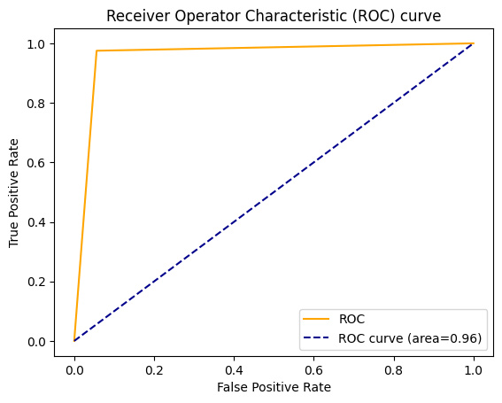

```python
y_pred=xg.predict(X_test)
print("confusion matrix:\n",
      confusion_matrix(y_test,y_pred))

print("Accuracy score:" ,accuracy_score(y_test,y_pred))
print("recall: ",recall_score(y_test,y_pred))
print("Precison: ",precision_score(y_test,y_pred))
print("F1-score: ", f1_score(y_test,y_pred))
print("Specifity: ",confusion_matrix(y_test, y_pred)[0,0] / (confusion_matrix(y_test, y_pred)[0,0] + confusion_matrix(y_test, y_pred)[0,1]))
auc=roc_auc_score(y_test,y_pred)
fpr, tpr, thresholds = roc_curve(y_test, y_pred)
plt.plot(fpr, tpr, color="orange", label="ROC")
plt.plot([0,1], [0,1], color="darkblue", linestyle="--", label="ROC curve (area=%0.2f)" % auc)
plt.xlabel("False Positive Rate")
plt.ylabel("True Positive Rate")
plt.title("Receiver Operator Characteristic (ROC) curve")
plt.legend()
plt.show()
```

# **Plot for viewing accuracy of all models:**

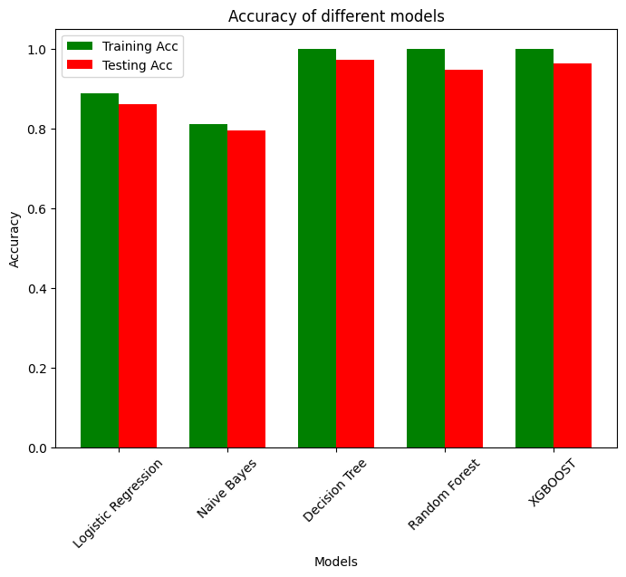

```python
# Model names
models = ["Logistic Regression", 'Naive Bayes',"Decision Tree","Random Forest","XGBOOST"]

# Training and testing accuracy for each model
train_acc = [0.889, 0.811, 1, 1, 1]
test_acc = [0.861, 0.794, 0.973, 0.947, 0.962]

# Width of bars
bar_width = 0.35

# X-coordinates for the bars
x_train = [i - bar_width/2 for i in range(len(models))]
x_test = [i + bar_width/2 for i in range(len(models))]

# Plot the bars for training and testing accuracy
plt.figure(figsize=(8,6))
plt.bar(x_train, train_acc, width=bar_width, label='Training Acc', color="green")
plt.bar(x_test, test_acc, width=bar_width, label='Testing Acc', color="red")

# Set the title, labels, and ticks for the plot
plt.title('Accuracy of different models')
plt.xlabel('Models')
plt.ylabel('Accuracy')
plt.xticks(range(len(models)), models, rotation=45)
plt.legend()

# Display the plot
plt.show()
```

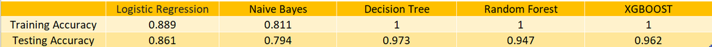

**RESULTS:**

1.Decison tree was our best model for this classification problem of Insurance Claim.

3.The decision to finalize the Decision Tree model over XGBoost was based on multiple factors such as interpretability, ease of implementation, and computational efficiency. Decision trees provide a clear and intuitive understanding of the decision-making process and the factors driving the predictions. Moreover, they are computationally efficient and do not require extensive hyperparameter tuning.

```python
#!jupyter nbconvert --to html 'Mini_Project_ML1_Task2_3_60009210068.ipynb'
```